# Malathion - Selection scan with outFlank

Luciano V Cosme

2023-12-18

# Analysis code

## 1. R libraries and software

```r
library(tidyverse)
library(colorout)
library(here)
library(ggplot2)
library(scales)
library(extrafont)
library(forcats)
library(ggrepel)
library(ggtext)
library(stats)
library(vcfR)
library(OutFLANK)
```

## 2. outFLANK

This tool does not directly account for population structure. It instead looks for loci that show a higher Fst than the neutral expectation, under a model of hierarchical population structure. The method is robust to hierarchical population structure and a range of demographic histories.

Check the documentation https://htmlpreview.github.io/?https://github.com/whitlock/OutFLANK/blob/master/inst/doc/OutFLANKAnalysis.html

“OutFLANK is an R package that implements the method developed by Whitlock and Lotterhos (2015) to use likelihood on a trimmed distribution of FST values to infer the distribution of FST for neutral markers. This distribution is then used to assign q-values to each locus to detect outliers that may be due to spatially heterogeneous selection.”

Clean env and memory

```r
# Remove all objects from the environment
rm(list = ls())

# Run the garbage collector to free up memory
gc()
```

```
##           used  (Mb) gc trigger (Mb) limit (Mb) max used  (Mb)
## Ncells 2278143 121.7    4117871  220         NA  4117871 220.0
## Vcells 3894807  29.8    8388608   64      32768  6582355  50.3
```

Check vignettes

```r
browseVignettes("OutFLANK")
```

```
## starting httpd help server ... done
```

### 2.1 OutFLANK analysis with quasi-independent set of SNPs

Extract the intergenic SNPs and do LD pruning

```bash
plink2 \
--bfile output/gwas/file2 \
--extract data/files/intergenic_SNPs.txt \
--indep-pairwise 50kb 1 0.1 \
--out output/outflank/indepSNP \
--silent;
grep 'samples\|variants\|remaining' output/outflank/indepSNP.log
```

```
## 84 samples (41 females, 43 males; 84 founders) loaded from
## 10157 variants loaded from output/gwas/file2.bim.
## --extract: 2077 variants remaining.
## 2077 variants remaining after main filters.
## --indep-pairwise (11 compute threads): 10/2077 variants removed.
```

Create vcf with intergenic SNPs that are not linked

```bash
plink2 \
--bfile output/gwas/file2 \
--extract output/outflank/indepSNP.prune.in \
--export vcf id-delim="." \
--make-bed \
--maf 0.01 \
--geno 0.2 \
--out output/outflank/intergenic \
--silent;
grep 'samples\|variants\|remaining' output/outflank/intergenic.log
```

```
## 84 samples (41 females, 43 males; 84 founders) loaded from
## 10157 variants loaded from output/gwas/file2.bim.
## --extract: 2067 variants remaining.
## --geno: 3 variants removed due to missing genotype data.
## 12 variants removed due to allele frequency threshold(s)
## 2052 variants remaining after main filters.
```

We need to import the data

```r
# Read your vcf file
vcf <- read.vcfR(here("output","outflank","intergenic.vcf"))
```

[output not shown]

```r
# Extract genotypes
geno <- vcfR::extract.gt(vcf)

# Extract locus names (positions)
locusNames <- vcfR::getPOS(vcf)

# Samples
sampleNames <- colnames(geno)

# Extract population names by splitting the sample names
# If your sample names contain population information.
popNames <- sapply(strsplit(sampleNames, "_"), "[", 1)

# Initialize new matrix for transformed genotypes
G <- matrix(NA, nrow = nrow(geno), ncol = ncol(geno))

# Recode genotypes
G[geno %in% c("0/0", "0|0")] <- 0
G[geno %in% c("0/1", "1/0", "1|0", "0|1")] <- 1
G[geno %in% c("1/1", "1|1")] <- 2

# Replace NA with 9 for missing data
G <- replace(G, is.na(G), 9)

# Check the counts of each genotype
table(as.vector(G))
```

```
##
##     0     1     2     9
## 78016 50157 41298  2897
```

```r
# Extract SNP names
snpNames <- vcfR::getID(vcf)

# Calculate FST with SNP names
my_fst <- MakeDiploidFSTMat(t(G), locusNames = snpNames, popNames = popNames)
```

```
## Calculating FSTs, may take a few minutes...
```

```r
head(my_fst)
```

```
##     LocusName        He          FST            T1        T2    FSTNoCorr
## 1 AX-93255719 0.2524005 -0.001937478 -0.0002461322 0.1270374 0.0133902817
## 2 AX-93257574 0.4840561 -0.010261840 -0.0024850913 0.2421682 0.0012683866
## 3 AX-93253527 0.4687500 -0.013542892 -0.0031749812 0.2344389 0.0006870299
## 4 AX-93252859 0.4319019  0.043295590  0.0096210862 0.2222186 0.0562513024
## 5 AX-93252845 0.4319019  0.052672837  0.0117880032 0.2237966 0.0699273701
## 6 AX-93248606 0.4346785  0.104905405  0.0242716488 0.2313670 0.1206120060
##       T1NoCorr  T2NoCorr meanAlleleFreq
## 1 0.0017013889 0.1270615      0.8518519
## 2 0.0003071809 0.2421824      0.4107143
## 3 0.0001610782 0.2344560      0.3750000
## 4 0.0125009131 0.2222333      0.6845238
## 5 0.0156508876 0.2238163      0.3154762
## 6 0.0279087583 0.2313929      0.6807229
```

Check the FST distribution

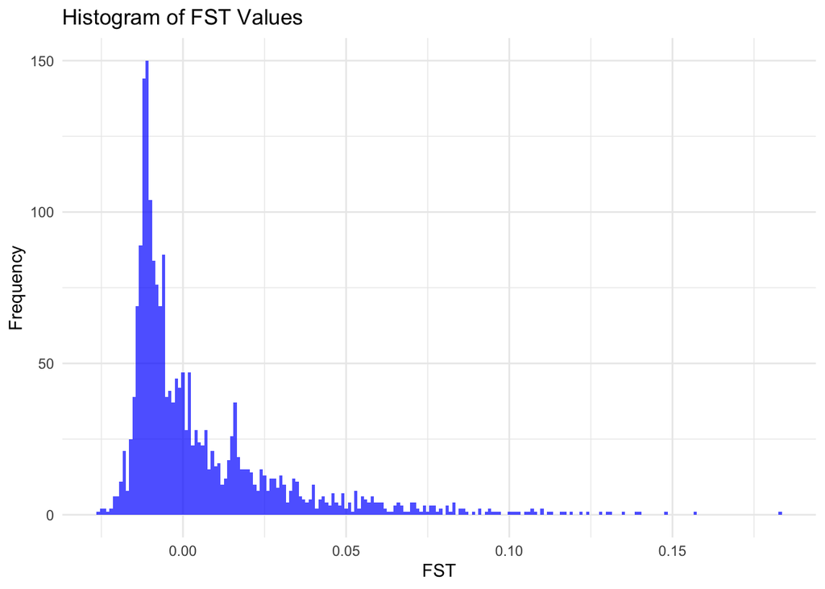

```r
# Create the histogram of FST values
ggplot(my_fst, aes(x=FST)) +
  geom_histogram(binwidth=0.001, fill="blue", alpha=0.7) +
  labs(title="Histogram of FST Values",
       x="FST",
       y="Frequency") +
  theme_minimal()
```

We can select the SNPs with low FST to use as neutral SNPs

```r
my_fst |>
  filter(FST < 0.018 & FST >= -0.02) |>
  # filter(FST < 0.05 & FST >=-0.1) |>
    # filter(FST < 0.1) |>
  dplyr::select(LocusName) -> neutral_snps

length(neutral_snps$LocusName)
```

```
## [1] 1631
```

```r
write.table(
  neutral_snps$LocusName,
  file = here("output", "outflank","neutral_SNPs.txt"),
  row.names = FALSE,
  quote = FALSE,
  col.names = FALSE,
  sep = "\n"
)
```

Create a vcf

```bash
plink2 \
--bfile output/outflank/intergenic \
--export vcf id-delim="." \
--extract output/outflank/neutral_SNPs.txt \
--out output/outflank/neutral \
--silent;
grep "samples\|variants" output/outflank/neutral.log
```

```
## 84 samples (41 females, 43 males; 84 founders) loaded from
## 2052 variants loaded from output/outflank/intergenic.bim.
## --extract: 1631 variants remaining.
## 1631 variants remaining after main filters.
```

Import the data.

```r
# Read your vcf file
vcf <- read.vcfR(here("output","outflank","neutral.vcf"))
```

[output not shown]

```r
# vcf <- read.vcfR(here("output","outflank","intergenic.vcf"))
# Extract genotypes
geno <- vcfR::extract.gt(vcf)

# Extract locus names (positions)
locusNames <- vcfR::getPOS(vcf)

# Samples
sampleNames <- colnames(geno)

# Extract population names by splitting the sample names
# If your sample names contain population information.
popNames <- sapply(strsplit(sampleNames, "_"), "[", 1)

# Initialize new matrix for transformed genotypes
G <- matrix(NA, nrow = nrow(geno), ncol = ncol(geno))

# Recode genotypes
G[geno %in% c("0/0", "0|0")] <- 0
G[geno %in% c("0/1", "1/0", "1|0", "0|1")] <- 1
G[geno %in% c("1/1", "1|1")] <- 2

# Replace NA with 9 for missing data
G <- replace(G, is.na(G), 9)

# Check the counts of each genotype
table(as.vector(G))
```

```
##
##     0     1     2     9
## 61715 40190 32927  2172
```

```r
# Extract SNP names
snpNames <- vcfR::getID(vcf)

# Calculate FST with SNP names
my_fst <- MakeDiploidFSTMat(t(G), locusNames = snpNames, popNames = popNames)
```

```
## Calculating FSTs, may take a few minutes...
```

```r
head(my_fst)
```

```
##     LocusName        He          FST            T1        T2    FSTNoCorr
## 1 AX-93255719 0.2524005 -0.001937478 -0.0002461322 0.1270374 0.0133902817
## 2 AX-93257574 0.4840561 -0.010261840 -0.0024850913 0.2421682 0.0012683866
## 3 AX-93253527 0.4687500 -0.013542892 -0.0031749812 0.2344389 0.0006870299
## 4 AX-93248590 0.2631135 -0.013258038 -0.0017442360 0.1315606 0.0004271019
## 5 AX-93233664 0.3866213 -0.012161097 -0.0023510421 0.1933248 0.0002720480
## 6 AX-93233669 0.2006094 -0.008119812 -0.0008160282 0.1004984 0.0039576758
##       T1NoCorr  T2NoCorr meanAlleleFreq
## 1 1.701389e-03 0.1270615      0.8518519
## 2 3.071809e-04 0.2421824      0.4107143
## 3 1.610782e-04 0.2344560      0.3750000
## 4 5.620030e-05 0.1315852      0.8441558
## 5 5.259698e-05 0.1933371      0.7380952
## 6 3.977646e-04 0.1005046      0.8869048
```

Check the FST distribution

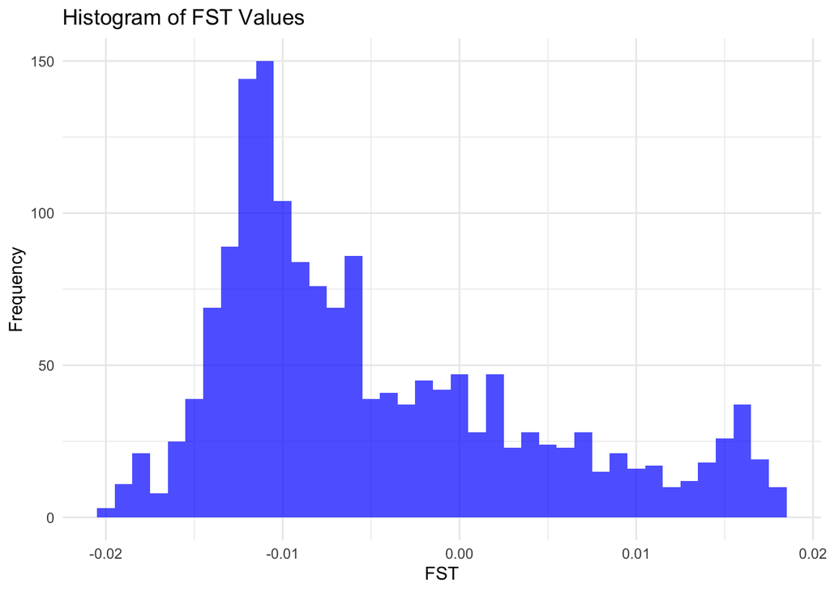

```r
# Create the histogram of FST values
ggplot(my_fst, aes(x=FST)) +
  geom_histogram(binwidth=0.001, fill="blue", alpha=0.7) +
  labs(title="Histogram of FST Values",
       x="FST",
       y="Frequency") +
  theme_minimal()
```

Data prep: decide which SNPs to use for calibrating the null distribution of Fst

```r
# Run OutFLANK to estimate the neutral FST distribution
out_trim <- OutFLANK(FstDataFrame = my_fst, Hmin = 0.1, NumberOfSamples = 60, qthreshold = 0.05)
str(out_trim)
```

```
## List of 6
##  $ FSTbar               : num -0.00495
##  $ FSTNoCorrbar         : num 0.0086
##  $ dfInferred           : num 2
##  $ numberLowFstOutliers : int 0
##  $ numberHighFstOutliers: int 0
##  $ results              :'data.frame':   1631 obs. of  15 variables:
##   ..$ LocusName       : chr [1:1631] "AX-93255719" "AX-93257574" "AX-93253527" "AX-93248590" ...
##   ..$ He              : num [1:1631] 0.252 0.484 0.469 0.263 0.387 ...
##   ..$ FST             : num [1:1631] -0.00194 -0.01026 -0.01354 -0.01326 -0.01216 ...
##   ..$ T1              : num [1:1631] -0.000246 -0.002485 -0.003175 -0.001744 -0.002351 ...
##   ..$ T2              : num [1:1631] 0.127 0.242 0.234 0.132 0.193 ...
##   ..$ FSTNoCorr       : num [1:1631] 0.01339 0.001268 0.000687 0.000427 0.000272 ...
##   ..$ T1NoCorr        : num [1:1631] 1.70e-03 3.07e-04 1.61e-04 5.62e-05 5.26e-05 ...
##   ..$ T2NoCorr        : num [1:1631] 0.127 0.242 0.234 0.132 0.193 ...
##   ..$ meanAlleleFreq  : num [1:1631] 0.852 0.411 0.375 0.844 0.738 ...
##   ..$ indexOrder      : int [1:1631] 1 2 3 4 5 6 7 8 9 10 ...
##   ..$ GoodH           : chr [1:1631] "goodH" "goodH" "goodH" "goodH" ...
##   ..$ qvalues         : num [1:1631] 0.785 0.949 0.949 0.949 0.949 ...
##   ..$ pvalues         : num [1:1631] 0.4216 0.2742 0.1535 0.0969 0.0623 ...
##   ..$ pvaluesRightTail: num [1:1631] 0.211 0.863 0.923 0.952 0.969 ...
##   ..$ OutlierFlag     : logi [1:1631] FALSE FALSE FALSE FALSE FALSE FALSE ...
```

Check the fit and make sure it looks good, especially in the right tail:

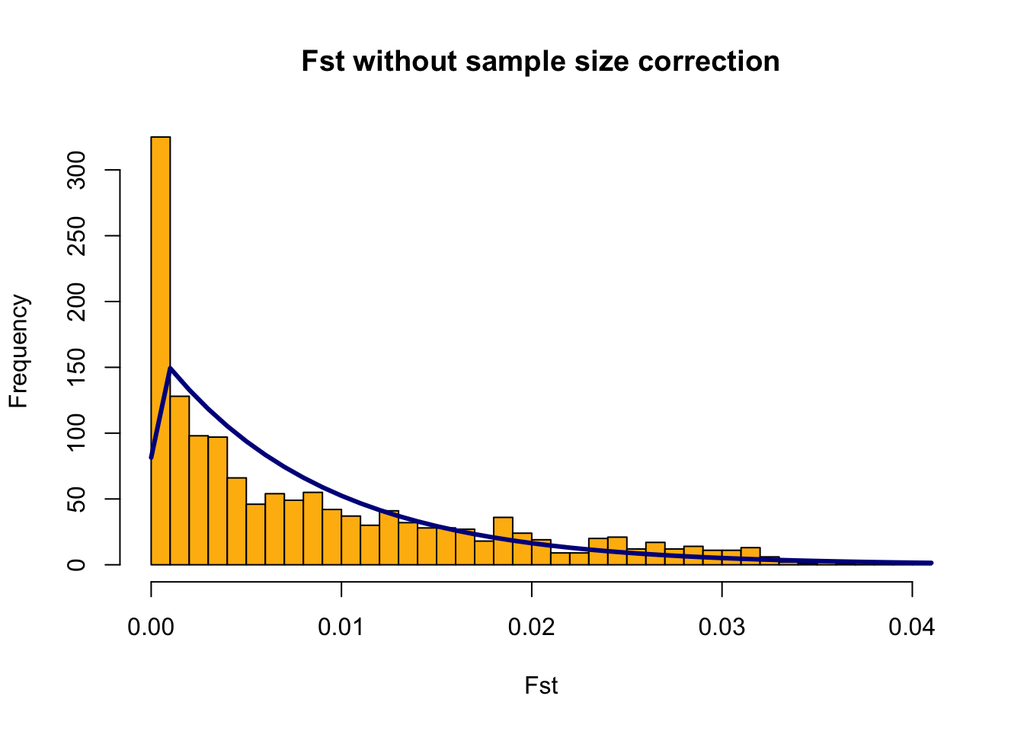

```r
OutFLANKResultsPlotter(
  out_trim,
  withOutliers = TRUE,
  NoCorr = TRUE,
  Hmin = 0.1,
  binwidth = 0.001,
  Zoom = FALSE,
  RightZoomFraction = 0.05,
  titletext = NULL
)
```

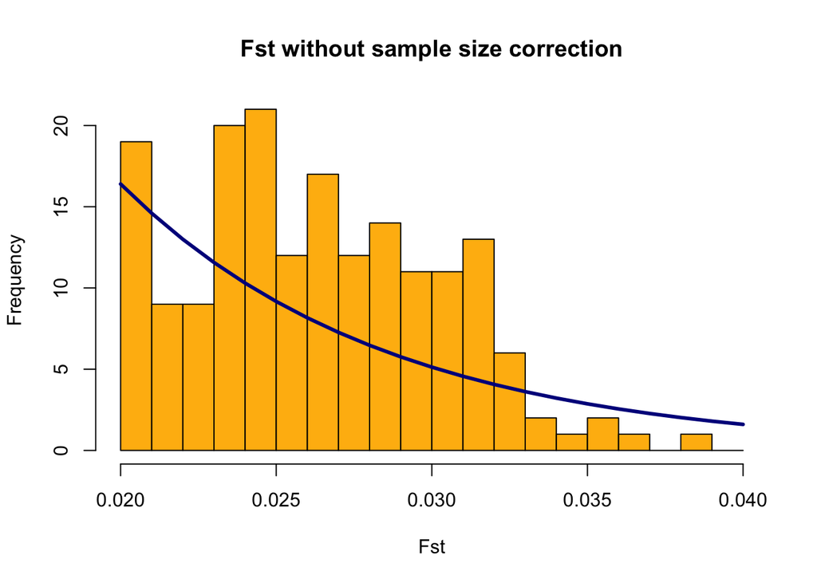

```r
## Zoom in on right tail
OutFLANKResultsPlotter(
  out_trim ,
  withOutliers = TRUE,
  NoCorr = TRUE,
  Hmin = 0.1,
  binwidth = 0.001,
  Zoom =
    TRUE,
  RightZoomFraction = 0.05,
  titletext = NULL
)
```

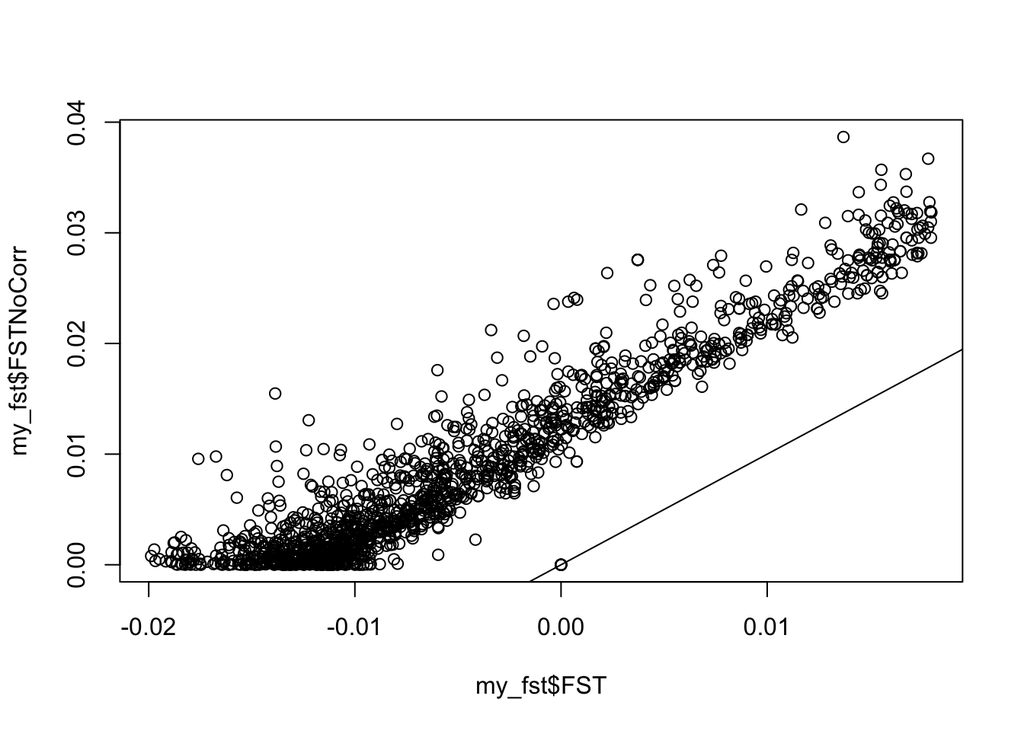

```r
plot(my_fst$FST, my_fst$FSTNoCorr)
abline(0,1)
```

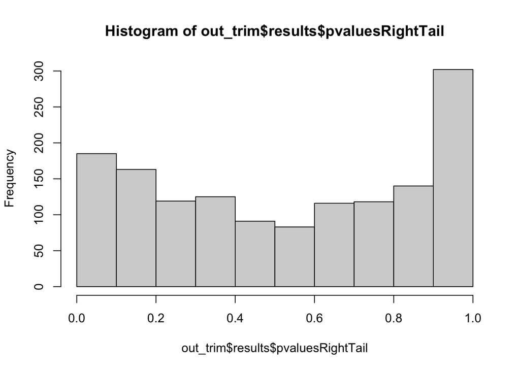

```r
hist(out_trim$results$pvaluesRightTail)
```

### 2.2 Using estimated neutral mean FST and df to calculate P-values for all loci

Now that we’ve estimated neutral mean FST and df to a quasi-independent set of SNPs, we can go and calculate P-values and q-values for all the loci in our dataset before prunning.

Note that it is important to run this code with the uncorrected FSTs (FSTNoCorr) and the uncorrected mean FST (FSTNoCorrbar).

Now we can use the entire data set to estimate the fst

Create a vcf - ld pruned data

```bash
plink2 \
--bfile output/gwas/file2 \
--export vcf id-delim="." \
--extract output/quality_control/indepSNP.prune.in \
--make-bed \
--out output/outflank/malathion \
--silent;
grep "samples\|variants" output/outflank/malathion.log
```

```
## 84 samples (41 females, 43 males; 84 founders) loaded from
## 10157 variants loaded from output/gwas/file2.bim.
## --extract: 10157 variants remaining.
## 10157 variants remaining after main filters.
```

Import the data

```r
# Read your vcf file
vcf2 <- read.vcfR(here("output","outflank","malathion.vcf"))
```

[output not shown]

```r
# Extract genotypes
geno2 <- vcfR::extract.gt(vcf2)

# Extract locus names (positions)
locusNames2 <- vcfR::getPOS(vcf2)

# Samples
sampleNames2 <- colnames(geno2)

# Extract population names by splitting the sample names
# If your sample names contain population information.
popNames2 <- sapply(strsplit(sampleNames2, "_"), "[", 1)

# Initialize new matrix for transformed genotypes
H <- matrix(NA, nrow = nrow(geno2), ncol = ncol(geno2))

# Recode genotypes
H[geno2 %in% c("0/0", "0|0")] <- 0
H[geno2 %in% c("0/1", "1/0", "1|0", "0|1")] <- 1
H[geno2 %in% c("1/1", "1|1")] <- 2

# Replace NA with 9 for missing data
H <- replace(H, is.na(H), 9)

# Check the counts of each genotype
table(as.vector(H))
```

```
##
##      0      1      2      9
## 411972 224331 198575  18310
```

```r
# Extract SNP names
snpNames <- vcfR::getID(vcf2)

# Use the option below for names if you want to make the plot without having to add the postion later on
locusNames2 <- vcfR::getPOS(vcf2)

# Calculate FST
my_fst2 <- MakeDiploidFSTMat(t(H), locusNames = locusNames2, popNames = popNames2)
```

```
## Calculating FSTs, may take a few minutes...
## [1] "10000 done of 10157"
```

```r
my_fst3 <- MakeDiploidFSTMat(t(H), locusNames = snpNames, popNames = popNames2) # with SNP id instead of position
```

```
## Calculating FSTs, may take a few minutes...
## [1] "10000 done of 10157"
```

```r
# Concatenate the SNP names and the SNP positions
locusNames3 <- paste(snpNames, locusNames2, sep = ".")

# Calculate FST with the combined names
my_fst4 <- MakeDiploidFSTMat(t(H), locusNames = locusNames3, popNames = popNames2)
```

```
## Calculating FSTs, may take a few minutes...
## [1] "10000 done of 10157"
```

```r
# Check output
head(my_fst2)
```

```
##   LocusName        He          FST            T1        T2   FSTNoCorr
## 1     47066 0.4726767  0.000946106  0.0002253957 0.2382351 0.015944479
## 2    104497 0.4404053 -0.005756334 -0.0012727951 0.2211121 0.008326668
## 3    122889 0.2524005 -0.001937478 -0.0002461322 0.1270374 0.013390282
## 4    179464 0.2276077 -0.004834258 -0.0005523395 0.1142553 0.007991597
## 5    183444 0.4672070 -0.009252574 -0.0021700958 0.2345397 0.008236327
## 6    424571 0.4795210  0.007066163  0.0017112280 0.2421722 0.019945329
##       T1NoCorr  T2NoCorr meanAlleleFreq
## 1 0.0037986213 0.2382405      0.6168831
## 2 0.0018412594 0.2211280      0.3273810
## 3 0.0017013889 0.1270615      0.8518519
## 4 0.0009131419 0.1142628      0.8690476
## 5 0.0019320672 0.2345787      0.3719512
## 6 0.0048305209 0.2421881      0.3988095
```

```r
head(my_fst3)
```

```
##     LocusName        He          FST            T1        T2   FSTNoCorr
## 1 AX-93255727 0.4726767  0.000946106  0.0002253957 0.2382351 0.015944479
## 2 AX-93255722 0.4404053 -0.005756334 -0.0012727951 0.2211121 0.008326668
## 3 AX-93255719 0.2524005 -0.001937478 -0.0002461322 0.1270374 0.013390282
## 4 AX-93255713 0.2276077 -0.004834258 -0.0005523395 0.1142553 0.007991597
## 5 AX-93255711 0.4672070 -0.009252574 -0.0021700958 0.2345397 0.008236327
## 6 AX-93255691 0.4795210  0.007066163  0.0017112280 0.2421722 0.019945329
##       T1NoCorr  T2NoCorr meanAlleleFreq
## 1 0.0037986213 0.2382405      0.6168831
## 2 0.0018412594 0.2211280      0.3273810
## 3 0.0017013889 0.1270615      0.8518519
## 4 0.0009131419 0.1142628      0.8690476
## 5 0.0019320672 0.2345787      0.3719512
## 6 0.0048305209 0.2421881      0.3988095
```

```r
head(my_fst4)
```

```
##            LocusName        He          FST            T1        T2   FSTNoCorr
## 1  AX-93255727.47066 0.4726767  0.000946106  0.0002253957 0.2382351 0.015944479
## 2 AX-93255722.104497 0.4404053 -0.005756334 -0.0012727951 0.2211121 0.008326668
## 3 AX-93255719.122889 0.2524005 -0.001937478 -0.0002461322 0.1270374 0.013390282
## 4 AX-93255713.179464 0.2276077 -0.004834258 -0.0005523395 0.1142553 0.007991597
## 5 AX-93255711.183444 0.4672070 -0.009252574 -0.0021700958 0.2345397 0.008236327
## 6 AX-93255691.424571 0.4795210  0.007066163  0.0017112280 0.2421722 0.019945329
##       T1NoCorr  T2NoCorr meanAlleleFreq
## 1 0.0037986213 0.2382405      0.6168831
## 2 0.0018412594 0.2211280      0.3273810
## 3 0.0017013889 0.1270615      0.8518519
## 4 0.0009131419 0.1142628      0.8690476
## 5 0.0019320672 0.2345787      0.3719512
## 6 0.0048305209 0.2421881      0.3988095
```

Note that it is important to run this code with the uncorrected FSTs (FSTNoCorr) and the uncorrected mean FST (FSTNoCorrbar).

```r
P1 <-
  pOutlierFinderChiSqNoCorr(
    my_fst4,
    Fstbar = out_trim$FSTNoCorrbar,
    dfInferred = out_trim$dfInferred,
    qthreshold = 0.05,
    Hmin = 0.1
  )
head(P1)
```

```
##            LocusName        He          FST            T1        T2   FSTNoCorr
## 1  AX-93255727.47066 0.4726767  0.000946106  0.0002253957 0.2382351 0.015944479
## 2 AX-93255722.104497 0.4404053 -0.005756334 -0.0012727951 0.2211121 0.008326668
## 3 AX-93255719.122889 0.2524005 -0.001937478 -0.0002461322 0.1270374 0.013390282
## 4 AX-93255713.179464 0.2276077 -0.004834258 -0.0005523395 0.1142553 0.007991597
## 5 AX-93255711.183444 0.4672070 -0.009252574 -0.0021700958 0.2345397 0.008236327
## 6 AX-93255691.424571 0.4795210  0.007066163  0.0017112280 0.2421722 0.019945329
##       T1NoCorr  T2NoCorr meanAlleleFreq   pvalues pvaluesRightTail   qvalues
## 1 0.0037986213 0.2382405      0.6168831 0.3132937       0.15664687 0.3452441
## 2 0.0018412594 0.2211280      0.3273810 0.7596173       0.37980865 0.5863965
## 3 0.0017013889 0.1270615      0.8518519 0.4216187       0.21080933 0.4165081
## 4 0.0009131419 0.1142628      0.8690476 0.7897933       0.39489665 0.5917647
## 5 0.0019320672 0.2345787      0.3719512 0.7676379       0.38381895 0.5891635
## 6 0.0048305209 0.2421881      0.3988095 0.1967607       0.09838036 0.2585409
##   OutlierFlag
## 1       FALSE
## 2       FALSE
## 3       FALSE
## 4       FALSE
## 5       FALSE
## 6       FALSE
```

```r
tail(P1)
```

```
##                   LocusName         He          FST            T1         T2
## 10118 AX-93218147.405537773 0.02352608 -0.011984251 -0.0001409713 0.01176305
## 10119 AX-93218150.405635006 0.03507653  0.019715591  0.0003512612 0.01781642
## 10122 AX-93218157.405775129 0.03591612 -0.009739765 -0.0001751199 0.01797989
## 10126 AX-93218170.406390214 0.08172219 -0.004206808 -0.0001728641 0.04109152
## 10139 AX-93240258.408190705 0.06887755  0.014837770  0.0005177738 0.03489566
## 10141 AX-93240262.408248599 0.04648526 -0.017981903 -0.0004179607 0.02324341
##          FSTNoCorr     T1NoCorr   T2NoCorr meanAlleleFreq pvalues
## 10118 0.0001241972 1.461027e-06 0.01176377     0.98809524      NA
## 10119 0.0311804009 5.555556e-04 0.01781746     0.98214286      NA
## 10122 0.0025463713 4.578650e-05 0.01798108     0.01829268      NA
## 10126 0.0113200794 4.651980e-04 0.04109494     0.95731707      NA
## 10139 0.0261662679 9.131419e-04 0.03489768     0.03571429      NA
## 10141 0.0002514074 5.844108e-06 0.02324557     0.97619048      NA
##       pvaluesRightTail qvalues OutlierFlag
## 10118               NA      NA          NA
## 10119               NA      NA          NA
## 10122               NA      NA          NA
## 10126               NA      NA          NA
## 10139               NA      NA          NA
## 10141               NA      NA          NA
```

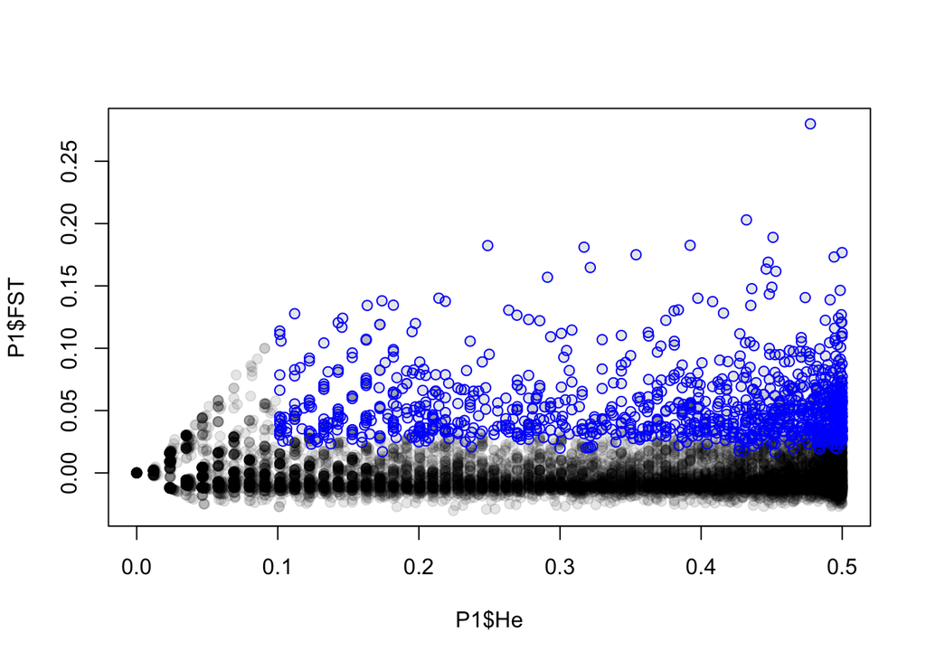

```r
# notice how the output is ordered differently
my_out <- P1$OutlierFlag==TRUE
plot(P1$He, P1$FST, pch=19, col=rgb(0,0,0,0.1))
points(P1$He[my_out], P1$FST[my_out], col="blue")
```

```r
# check the P-value histogram for the full set of data
# if there are outliers, it should look flat with an inflation near 0
```

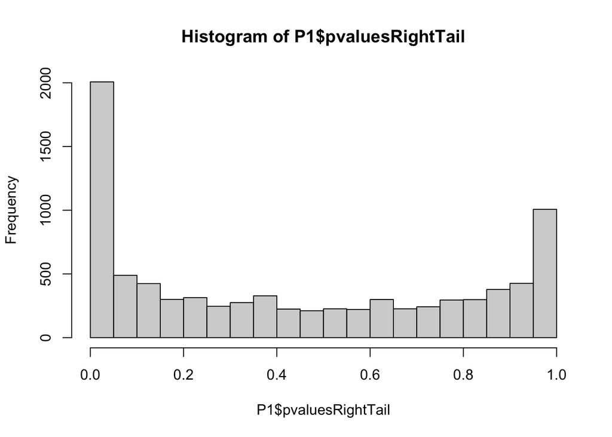

```r
hist(P1$pvaluesRightTail)
```

Highlight outliers on Manhattan Plot

For publication, we want to show the accurate estimate of FST, not the uncorrected estimate. Remember to exclude those low H loci!

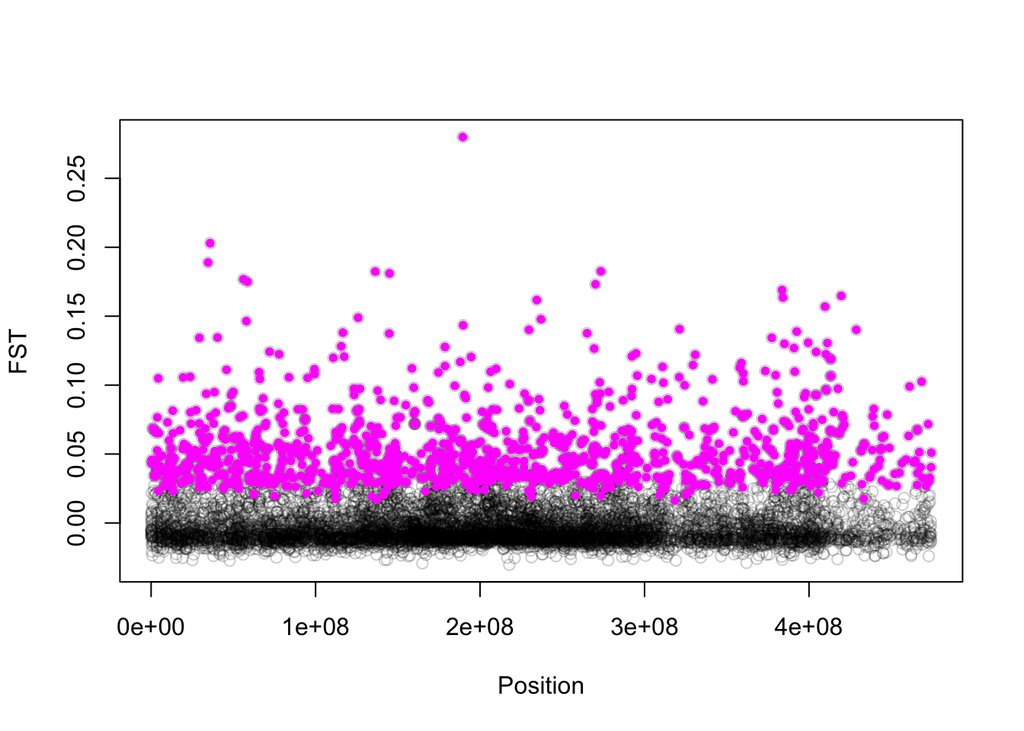

```r
# Use the separate() function to split the LocusName column
P1 <- P1 |>
  separate(LocusName, into = c("SNP_id", "LocusName"), sep = "\\.")

# Create plot
plot(P1$LocusName[P1$He>0.1], P1$FST[P1$He>0.1],
     xlab="Position", ylab="FST", col=rgb(0,0,0,0.2))
  points(P1$LocusName[my_out], P1$FST[my_out], col="magenta", pch=20)
```

```r
#   ____________________________________________________________________________
#   import the bim file with the SNP data                                   ####
snps <-
  read_delim(                    # to learn about the options use here, run ?read_delim on the console.
    here(
      "output", "outflank", "malathion.bim"
    ),                           # use library here to load it
    col_names      = FALSE,      # we don't have header in the input file
    show_col_types = FALSE,      # suppress message from read_delim
    col_types      = "ccidcc"    # set the class of each column
  )
#
# set column names
colnames(
  snps
) <-                             # to add a header in our tibble
  c(
    "Scaffold", "SNP", "Cm", "Position", "Allele1", "Allele2"
  )
#
# check the tibble
head(snps)
```

```
## # A tibble: 6 × 6
##   Scaffold SNP            Cm Position Allele1 Allele2
##   <chr>    <chr>       <int>    <dbl> <chr>   <chr>
## 1 1        AX-93255727     0    47066 A       T
## 2 1        AX-93255722     0   104497 A       T
## 3 1        AX-93255719     0   122889 A       T
## 4 1        AX-93255713     0   179464 C       T
## 5 1        AX-93255711     0   183444 C       T
## 6 1        AX-93255691     0   424571 G       A
```

```r
# Use the separate() function to split the LocusName column
my_fst4 <- my_fst4 |>
  separate(LocusName, into = c("SNP_id", "LocusName"), sep = "\\.")

# Merge the data frames
merged_df <- merge(my_fst4, snps, by.x = "SNP_id", by.y = "SNP")

# Rename the column
merged_df <- rename(merged_df, Chromosome = Scaffold)

# View the first few rows of the merged data frame
head(merged_df)
```

```
##        SNP_id LocusName         He          FST            T1         T2
## 1 AX-93213918 242643229 0.16262755  0.017914090  0.0014803144 0.08263409
## 2 AX-93213924 184465554 0.42283163  0.032443551  0.0070092686 0.21604505
## 3 AX-93213930 106521244 0.46122416 -0.005999970 -0.0013887552 0.23146036
## 4 AX-93213933 106394391 0.43190193 -0.003550867 -0.0007702375 0.21691530
## 5 AX-93213939 106336506 0.02352608  0.015953829  0.0001902899 0.01192754
## 6 AX-93213941 106326102 0.42743764 -0.010255623 -0.0021967433 0.21419892
##     FSTNoCorr     T1NoCorr   T2NoCorr meanAlleleFreq Chromosome Cm  Position
## 1 0.031933450 0.0026389802 0.08264000      0.9107143          1  0 242643229
## 2 0.042739102 0.0092340565 0.21605640      0.6964286          2  0 184465554
## 3 0.007407144 0.0017145524 0.23147279      0.3607595          3  0 106521244
## 4 0.008972760 0.0019464534 0.21692916      0.6845238          3  0 106394391
## 5 0.027559055 0.0003287311 0.01192824      0.9880952          3  0 106336506
## 6 0.004610571 0.0009876543 0.21421517      0.3095238          3  0 106326102
##   Allele1 Allele2
## 1       G       T
## 2       G       A
## 3       T       C
## 4       A       G
## 5       C       T
## 6       G       C
```

Use ggplot to make a new plot

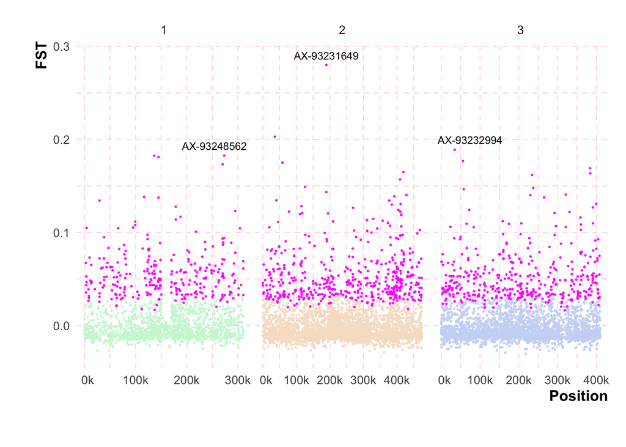

```r
# Subset dataframe for He > 0.1
df_sub <- subset(merged_df, He > 0.1)

# Adjust my_out condition to fit merged_df
my_out <- P1$SNP_id[P1$OutlierFlag == TRUE]

# Save it
write.table(
  my_out,
  file = here("output", "outflank","SNPs_outFlank.txt"),
  row.names = FALSE,
  quote = FALSE,
  col.names = FALSE,
  sep = "\n"
)

# Create a new column in the dataframe to define highlight points based on my_out
df_sub$highlight <- ifelse(df_sub$SNP_id %in% my_out, TRUE, FALSE)

# source the plotting function
source(
  here(
    "scripts", "analysis", "my_theme2.R"
  )
)

# Custom label function
k_format <- function(x) {
  paste0(format(x / 1e6, big.mark = "", scientific = FALSE), "k")
}

# Set colors for the chromosomes
color_vector <- c("#CCF6D6", "#F6E1CC", "#CCD8F6")  # Add or remove colors as needed.
names(color_vector) <- unique(df_sub$Chromosome)  # Make sure unique(df_sub$Chromosome) gives all unique Chromosome values.

# Filter data to include only the highest FST value for each chromosome
highest_FST <- df_sub[which(df_sub$highlight == TRUE), ]
highest_FST <- highest_FST[which(highest_FST$FST == ave(highest_FST$FST, highest_FST$Chromosome, FUN = max)), ]

# Create the plot
ggplot(df_sub, aes(x = Position, y = FST)) +
  geom_point(aes(color = Chromosome),
             data = subset(df_sub, highlight == FALSE),
             size = .3) +
  geom_point(
    color = "magenta",
    data = subset(df_sub, highlight == TRUE),
    size = .3
  ) +
  scale_color_manual(values = color_vector, guide = "none") +
  labs(x = "Position", y = "FST", caption = "") +
  facet_wrap(~ Chromosome, scales = "free_x") +
  scale_x_continuous(labels = k_format) +
  my_theme() +
  theme(panel.spacing = unit(.2, "lines"),
        plot.margin = unit(c(1, 1, 2, 2), "lines"),
        plot.caption = element_markdown(face = "italic", color = "#574E4E")) +
  # Annotate only the highest highlighted point for each chromosome
  geom_text_repel(
    data = highest_FST,
    aes(label = SNP_id),
    size = 3,
    nudge_y = 0.01,
    segment.color = NA,
    max.overlaps = Inf # Set to 'Inf' to show all annotations
  )
```

```r
# Save the plot
ggsave(
  here(
    "output", "outflank", "figures", "outFlank_outliers.pdf"
  ),
  width  = 8,
  height = 5,
  units  = "in"
)
```